# FigureYa87fish

小丫画图出品

2019-4-14

欢迎关注“小丫画图”公众号，同名知识星球等你加入

小丫微信: epigenomics E-mail: figureya@126.com

作者：蜗牛，欢迎关注作者公众号：[Kataegis-癌症基因组进化中那些大事件之一](https://mp.weixin.qq.com/s/_nTV5lbtRBEABW8DJg-YiA)

小丫编辑校验

## 需求描述

用R画文章里的这种肿瘤克隆进化的图。

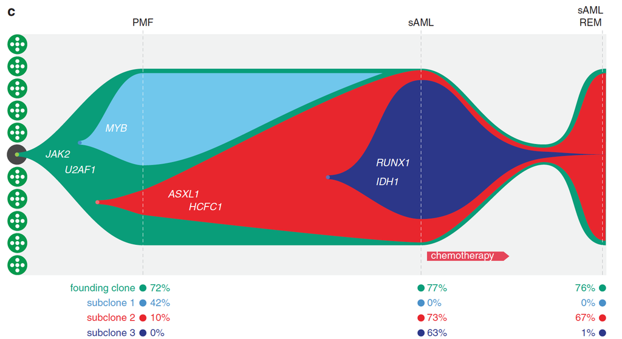

出自https://www.nature.com/articles/leu2014289

## 应用场景

Create timecourse “fish plots” that show changes in the clonal architecture of tumors, https://github.com/chrisamiller/fishplot

展示肿瘤细胞克隆进化的时间、比例等信息。

像例文那样，在三维时间节点上共鉴定到4个克隆群，我们可以看到其中founding clone 在三个时间点上占比都非常高，70%左右，除去这个主克隆外，还有三个亚克隆，在三个时间点上变化比较大，其中主要是subclone 1 的逐渐消失，subclone2 的逐渐扩增以及subclone 3的从无到有。

**题外话：**还有一个R包timescape，画clonal evolution这种鱼图也很美，https://bioconductor.org/packages/release/bioc/vignettes/timescape/inst/doc/timescape_vignette.html。

克隆进化图有点像sankey，我拿来FigureYa25sankey对比着看，理解更透彻。

## 环境设置

使用国内镜像安装包

```r
options("repos"= c(CRAN="https://mirrors.tuna.tsinghua.edu.cn/CRAN/"))
options(BioC_mirror="http://mirrors.ustc.edu.cn/bioc/")

install.packages("devtools")
library(devtools)
install_github("chrisamiller/fishplot")
```

加载包

```r
library(fishplot)
Sys.setenv(LANGUAGE = "en") #显示英文报错信息
options(stringsAsFactors = FALSE) #禁止chr转成factor
```

## 输入数据

需要三种输入：

- easy_input.txt，每行表示每个克隆群在不同时间节点的VAF/CCF 占比，每列表示每个时间节点中各个克隆簇的情况。
- timepoints，用来定义easy_input.txt的四列对应的4个时间节点。其中therapyTime列是化疗后休复期推断出的克隆群整体状况。
- parents，与时间节点相对应的各个克隆群进化关系。例图中，“0”表示主克隆，“1, 1”表示在主克隆之后有两个平行发展的亚克隆簇，“3”表示在这个克隆簇发生时，已经有两次克隆事件。进一步根据各个时间节点，各个克隆簇占比情况，脚本便可实现。为便于理解parents的写法，结尾附上了几个例子。

```r
frac <- read.table("easy_input.txt", header=T, sep='\t',row.names=1)
frac
```

```
##               PMF sAML therapyTime Saml_REM
## foundingclone  72   77           5       76
## subclone1      42    0           0        0
## subclone2      10   73           4       67
## subclone3       0   63           2        1
```

```r
frac.table <- as.matrix(frac)
timepoints <- c(0,75,110,120) #决定了鱼头、鱼身、鱼尾的长度
parents <- c(0,1,1,3)
```

**题外话：**除了用上述方法构建输入以外，还可以用CloneEvol输出的结果作为输入，fisherplot可以跟ClonEvol（擅长画树枝图）无缝对接，详见：https://github.com/chrisamiller/fishplot里的“clonevol integration”

## 开始画图

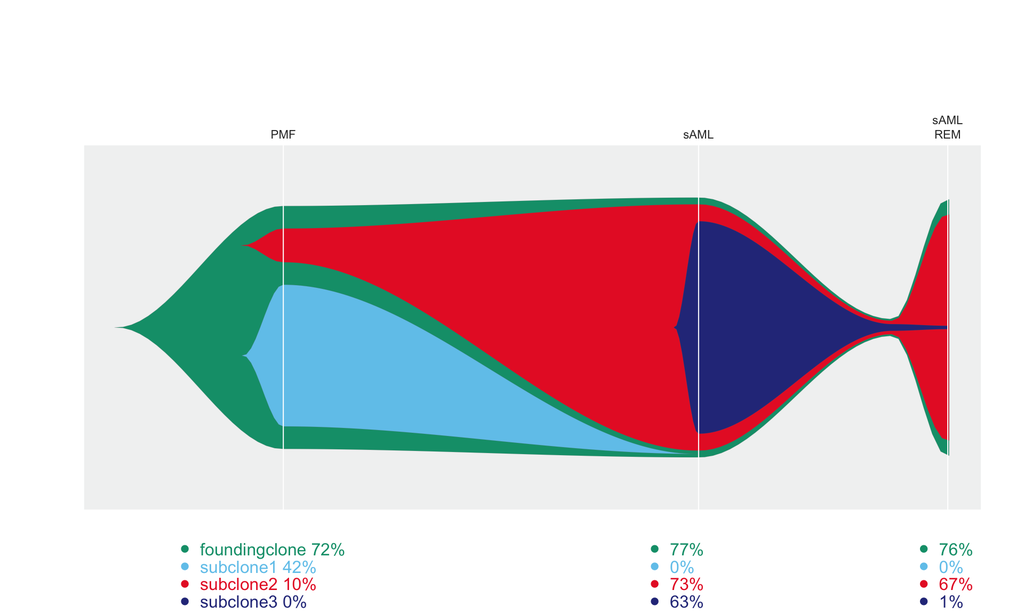

```r
fish <- createFishObject(frac.table, parents, timepoints)

#设置每种clone的颜色
fish <- setCol(fish, c("#099D79", "#70C7EC", "#E8262D","#2C3789"))
fish <- layoutClones(fish)

#pdf('fish.pdf', width=10, height=6)
par(mar = par()$mar + c(0,0,3,0)) #在底部留出画图例的地方

fishPlot(fish, shape = "spline", #spline，圆滑的；或polygon，直的
         #title.btm = "Clonal architecture of tumors", #左下角可以写字
         cex.title = 1.2, #字号
         pad.left = 0.25, #鱼头的边的倾斜角度

         vlines = timepoints[c(1:2,4)], #画三条竖直实线
         col.vline = "white", #线的颜色
         vlab = c("PMF", "sAML", "sAML\nREM"), #竖线对应的文字，在画竖线的前提下才能写字

         bg.col = c("#F1F2F2","#F1F2F2","#F1F2F2"), #灰色背景
         border = 0.1 #每个clone的轮廓线的宽度
         )

#如果三条竖线要画成虚线，就运行下面这行
#abline(v=timepoints[c(1:2,4)], col="white", lty=2, lwd=1)

#添加clone的图例
par(xpd = T)
legend("bottomright",
       inset=c(.7,-.3), #把图例画到图外，根据自己的鱼调整
       pch=16, bty="n",
       col=fish@col, text.col = fish@col,
       legend = paste0(row.names(frac)," ",frac$PMF,"%"))

legend("bottomright",
       inset=c(.3,-.3),
       pch=16, bty="n",
       col=fish@col, text.col = fish@col,
       legend = paste0(frac$sAML,"%"))

legend("bottomright",
       inset=c(.0,-.3),
       pch=16, bty="n",
       col=fish@col, text.col = fish@col,
       legend = paste0(frac$Saml_REM,"%"))
```

```r
#dev.off()
```

## 后期加工处理

前面输出的fish.pdf文件是矢量图，可以用illustrator等工具编辑，例如添加例文中的点、基因名，移动文字位置等等。

或者用[export包](https://mp.weixin.qq.com/s/QziYUmpag1MQRkN_xfvZJQ)导出矢量图，用ppt就能编辑。

## 附

如果有更多克隆，要怎样设置parents，能再举个例子吗？

```r
frac.table <- read.table("easy_input2.txt", header=T, sep='\t', row.names=1)
frac.table
```

```
##                 Primary Time1 Time2 mete
## founding_clone1      60     2     2   20
## subclone1            50     2     2    0
## subclone2            30     2     2    0
## founding_clone2       1     2     4   79
## subclone3             0     0     2   50
## subclone4             0     0     1   25
```

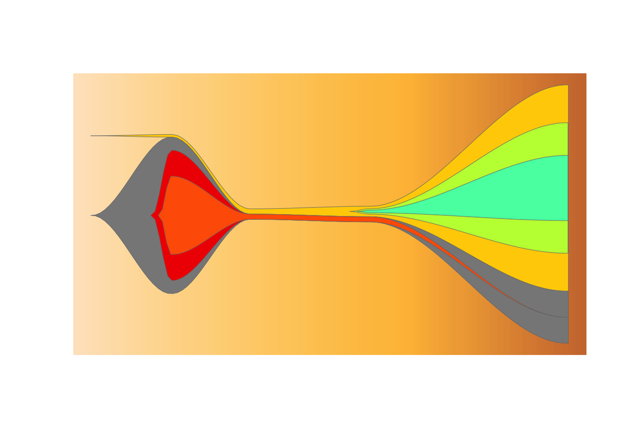

```r
frac.table <- as.matrix(frac.table)
timepoints <- c(0,30,75,150)
parents <- c(0,1,2,0,4,5)

#pdf('fish2.pdf', width=8, height=5)
fish <- createFishObject(frac.table, parents, timepoints)
fish <- layoutClones(fish)
fishPlot(fish,shape="spline")
```

```r
#dev <- dev.off()
```

再进一步，互相对比着看fishplot自带的三条鱼https://github.com/chrisamiller/fishplot对应的代码：https://github.com/chrisamiller/fishplot/blob/master/tests/test.R，就能掌握写parents的规律。